# Number and Share of Public-School Children Experiencing Homelessness

Author

Manuel Alcalá Kovalski

Published

February 26, 2026

## Overview

This program calculates metrics for the **Housing Stability** predictor:

- **Count**: Number of public-school students experiencing homelessness
- **Share**: Proportion of enrolled students experiencing homelessness

**Geography:** place **Years:** 2014, 2015, 2016, 2017, 2018, 2019, 2020, 2021, 2022

### Data Notes

- **Deduplication**: Data are unduplicated by LEA, but students who switch LEAs within a geography may be counted multiple times.
- **Data source**: EdFacts (2014-2018) and EdDataExpress (2019+) for homeless counts; CCD for enrollment denominators.
- **Race/ethnicity data**: Only available for 2019+. Subgroup shares use race-specific enrollment as denominator (e.g., Black homeless / Black enrolled).

### Suppression Methodology

Suppression in this metric occurs at two stages: the source data (EdFacts) and post-aggregation rules applied after rolling up LEAs to the county/place level.

**1. Source-level suppression (EdFacts “S” values)**

EdFacts marks LEA-level counts as “S” when the value is between 0 and 2 students, to protect student privacy. If only one LEA in a state-year has a suppressed value, the next-smallest value is also suppressed (complementary suppression) to prevent back-calculation from published totals. See the [LEA Homeless Enrolled Public File Documentation](https://www2.ed.gov/about/inits/ed/edfacts/data-files/lea-homeless-enrolled-sy2019-20-public-file-documentation.docx) for the exact suppression rules, [EdFacts File Specification 118](https://www.ed.gov/data/edfacts-initiative/edfacts-resources/edfacts-file-specifications/edfacts-file-specifications-sy-2023-24) (DG 655), and the [NCHE data page](https://nche.ed.gov/data-and-stats/).

**2. Midpoint imputation**

We replace each “S” with 1 (the midpoint of the 0-2 range) so that suppressed LEAs contribute to county/place aggregates rather than being dropped entirely. To quantify the uncertainty this introduces, we carry a lower bound of 0 and an upper bound of 2 for each suppressed cell. When a state-year has two or fewer suppressed LEAs, the upper bound is set to the minimum observed value in that state-year instead of 2, because complementary suppression means at least one of those cells had a true value above 2.

**3.Post-aggregation suppression (apply-suppression-rules chunk)**

After aggregation to the county/place level we apply five additional rules that go beyond the source “S” values:

| Rule | Condition | Action |
| --- | --- | --- |
| 1 | Total homeless count < 10 | Suppress all metrics (count, share, quality) |
| 2 | Total homeless count 10-29 | Set quality flag to 3 |
| 3 | Any share > 1 | Suppress that subgroup (impossible value from enrollment mismatch) |
| 4 | Race subgroup sum outside 70-110% of total | Suppress all race metrics |
| 5 | Any count ≤ 2 after aggregation | Re-suppress (cell size too small at geography level) |

Rules 1-2 ensure that small-count geographies are either suppressed or flagged. Rules 3-4 catch data-quality issues from enrollment-denominator mismatches. Rule 5 re-applies cell-size suppression after LEA-to-geography aggregation, since some geographies contain only one LEA whose suppressed value was imputed.

### Quality Flags

| Score | Criteria |
| --- | --- |
| 1 | Upper/lower bound ratio ≤ 1.05 |
| 2 | Upper/lower bound ratio between 1.05 and 1.1 |
| 3 | Ratio > 1.1, or enrollment < 30, or count between 10-30 |
| NA | Count < 10, share > 1, or race totals outside 70-110% of total |

## Setup

```r
library(tidyverse)
library(here)
library(janitor)
library(educationdata)
library(glue)

options(scipen = 999)

# Validate geography parameter
stopifnot(
"params$geography must be 'county' or 'place'" =
    params$geography %in% c("county", "place")
)

# Define paths
data_dir <- here("12_housing-stability", "data")
raw_dir <- here(data_dir, "raw")
final_dir <- here(data_dir, "final")

# Create directories if needed
walk(c(data_dir, raw_dir, final_dir), dir.create, showWarnings = FALSE, recursive = TRUE)

# Geography-specific settings
geo_settings <- list(
  county = list(
    crosswalk_file = here("geographic-crosswalks", "data", "county-populations.csv"),
    geo_var = "county",
    ccd_geo_field = "county_code",
    id_width = 3

),
  place = list(
    crosswalk_file = here("geographic-crosswalks", "data", "place-populations.csv"),
    geo_var = "place",
    ccd_geo_field = "city_location",
    id_width = 5
  )
)

settings <- geo_settings[[params$geography]]
```

## Load Geographic Crosswalk

```r
crosswalk <- read_csv(settings$crosswalk_file, show_col_types = FALSE) |>
  mutate(
    state = str_pad(state, width = 2, pad = "0"),
    !!settings$geo_var := str_pad(
      .data[[settings$geo_var]],
      width = settings$id_width,
      pad = "0"
    )
  )

if (params$geography == "place") {
  # For place geography, we need city names for matching to CCD
  crosswalk <- crosswalk |>
    rename(city_name_original = place_name) |>
    mutate(
      # Normalize city names to match CCD city_location field
      city_name = city_name_original |>
        str_remove(" town$") |>
        str_remove(" village$") |>
        str_remove(" municipality$") |>
        str_remove(" urban county$") |>
        str_remove(" city$") |>
        str_to_title(),
      # Hardcoded fixes for specific city name mismatches
      city_name = case_when(
        city_name == "San Buenaventura (Ventura)" ~ "Ventura",
        city_name == "Athens-Clarke County Unified Government (Balance)" ~ "Athens",
        city_name == "Augusta-Richmond County Consolidated Government (Balance)" ~ "Augusta",
        city_name == "Macon-Bibb County" ~ "Macon",
        city_name == "Boise City" ~ "Boise",
        city_name == "Lexington-Fayette" ~ "Lexington",
        city_name == "Louisville/Jefferson County Metro Government (Balance)" ~ "Louisville",
        city_name == "Nashville-Davidson Metropolitan Government (Balance)" ~ "Nashville",
        city_name == "Mcallen" ~ "Mcallen",
        city_name == "Mckinney" ~ "Mckinney",
        TRUE ~ city_name
      )
    ) |>
    select(-population, -city_name_original, -state_name, -in_universe)
} else {
  crosswalk <- crosswalk |>
    select(-population, -state_name, -county_name, -in_universe)
}

# Filter crosswalk to requested years (crosswalk already has year column)
crosswalk_years <- crosswalk |>
  filter(year %in% params$years)
```

## Download CCD District Data

The Common Core of Data (CCD) provides district-level enrollment and geographic information.

```r
# Download CCD district directory data
message("Downloading CCD district directory data...")

ccd_directory <- map_dfr(params$years, function(yr) {
  message(glue("  Year {yr}...
"))

  # Select columns based on geography
  cols <- if (params$geography == "county") {
    c("year", "leaid", "county_code", "enrollment")
  } else {
    c("year", "leaid", "county_code", "city_location", "enrollment")
  }

  get_education_data(
    level = "school-districts",
    source = "ccd",
    topic = "directory",
    filters = list(year = yr),
    add_labels = FALSE
  ) |>
    select(all_of(cols)) |>
    filter(!is.na(county_code))
})

# Process geographic identifiers
ccd_directory <- ccd_directory |>
  mutate(
    county_code = str_pad(county_code, width = 5, pad = "0"),
    state = str_sub(county_code, 1, 2),
    county = str_sub(county_code, 3, 5)
  ) |>
  filter(str_length(county) == 3)

if (params$geography == "place") {
  # Normalize city names for matching
  ccd_directory <- ccd_directory |>
    mutate(
      city_name = city_location |>
        str_to_lower() |>
        str_to_title()
    )
}
```

```r
# Race data only available for 2019+
race_years <- params$years[params$years >= 2019]
has_race_data <- length(race_years) > 0

if (has_race_data) {
  # Download CCD enrollment by race/ethnicity
  message("Downloading CCD enrollment by race...")

  ccd_race <- map_dfr(race_years, function(yr) {
    message(glue("  Year {yr}..."))

    # In the CCD enrollment data, grade = 99 is the "total across all grades"
    # code and sex = 99 is the "total across both sexes" code. These are NCES
    # aggregate indicator values, not actual grade levels. Without these filters,
    # the API returns separate rows for every grade-by-sex combination, which
    # would need to be summed to get district-level totals.
    get_education_data(
      level = "school-districts",
      source = "ccd",
      topic = "enrollment",
      subtopic = "race",
      filters = list(year = yr, grade = 99, sex = 99),
      add_labels = FALSE
    ) |>
      select(year, leaid, race, enrollment) |>
      filter(race != 99)
  })

  # Reshape to wide format with race-specific enrollment
  ccd_race_wide <- ccd_race |>
    mutate(
      race_var = case_when(
        race == 1 ~ "enroll_white",
        race == 2 ~ "enroll_black",
        race == 3 ~ "enroll_hispanic",
        race == 4 ~ "enroll_asian",
        race == 5 ~ "enroll_amin_an",
        race == 6 ~ "enroll_nh_pi",
        race == 7 ~ "enroll_twomore",
        TRUE ~ NA_character_
      )
    ) |>
    filter(!is.na(race_var)) |>
    select(-race) |>
    pivot_wider(
      names_from = race_var,
      values_from = enrollment,
      values_fill = 0
    ) |>
    mutate(
      # Combine smaller race categories into "other"
      enroll_other = enroll_asian + enroll_amin_an + enroll_nh_pi + enroll_twomore
    ) |>
    select(year, leaid, enroll_white, enroll_black, enroll_hispanic, enroll_other)

  # Merge CCD datasets
  ccd_merged <- ccd_directory |>
    left_join(ccd_race_wide, by = c("year", "leaid"))
} else {
  ccd_merged <- ccd_directory
}
```

## Download EdDataExpress Homelessness Data

EdDataExpress publishes homeless student enrollment data (Data Group 655).

### Manual Download Instructions for 2022-23 Data

Due to changes in the EdDataExpress website, data for 2022-23 must be manually downloaded. The website has known performance issues (documented December 2024):

- The “Reset Filters” button does not work properly
- Filters may disappear or the page may appear blank - refresh and try again
- Datasets are limited to 150,000 rows
- The default changed to show only one state (Alabama)

**Note:** As of February 2026, 2023-24 data is not yet available on EdDataExpress.

**Step-by-step instructions:**

1. Go to: https://eddataexpress.ed.gov/download/data-builder/data-download-tool
2. **Clear pre-set filters first**: For each filter on the left menu (State, Level, School Year, Population), click “Deselect All” to clear the defaults
3. **Set filters in this order** (important - set other filters BEFORE state):
   - **Level**: Select “Local Education Agency”
   - **School Year**: Select “2022-2023”
   - **Population**: Select “Homeless Students”
   - **State**: Leave empty (all states) or select specific states
4. Verify **Data Group = 655** (“Homeless students enrolled”) is shown in results
5. Click “Download Data”
6. Save to: `12_housing-stability/data/raw/`
   - Save as `2022-23 LEA homeless student data.csv`

**Alternatively**, the 2022-23 file is available on Box in the `Metrics_2025_round` folder.

```r
# Download URLs for available years
# 2014-2018: EdFacts direct CSV files from ed.gov
# 2019-2021: EdDataExpress zip files
# 2022+: Requires manual download due to EdDataExpress website changes
download_urls <- tribble(
  ~year, ~url, ~is_zip,
  2014, "https://www2.ed.gov/about/inits/ed/edfacts/data-files/lea-homeless-enrolled-sy2014-15.csv", FALSE,
  2015, "https://www2.ed.gov/about/inits/ed/edfacts/data-files/lea-homeless-enrolled-sy2015-16.csv", FALSE,
  2016, "https://www2.ed.gov/about/inits/ed/edfacts/data-files/lea-homeless-enrolled-sy2016-17.csv", FALSE,
  2017, "https://www2.ed.gov/about/inits/ed/edfacts/data-files/lea-homeless-enrolled-sy2017-18.csv", FALSE,
  2018, "https://www2.ed.gov/about/inits/ed/edfacts/data-files/lea-homeless-enrolled-sy2018-19-wide.csv", FALSE,
  2019, "https://eddataexpress.ed.gov/sites/default/files/data_download/EID_6526/SY1920_FS118_DG655_LEA_data_files.zip", TRUE,
  2020, "https://eddataexpress.ed.gov/sites/default/files/data_download/EID_8321/SY2021_FS118_DG655_LEA_data_files.zip", TRUE,
  2021, "https://eddataexpress.ed.gov/sites/default/files/data_download/EID_11718/SY2122_FS118_DG655_LEA_data_files.zip", TRUE
)

# Download files (zip for 2019+, direct CSV for 2014-2018)
pwalk(download_urls, function(year, url, is_zip) {
  if (is_zip) {
    zip_file <- here(raw_dir, glue("EdDataEx_Homelessness_{year}.zip"))
    if (!file.exists(zip_file)) {
      message(glue("Downloading EdDataExpress data for {year}..."))
      download.file(url, zip_file, mode = "wb")
      unzip(zip_file, exdir = raw_dir)
    }
  } else {
    csv_file <- here(raw_dir, glue("EDFacts_Homelessness_{year}.csv"))
    if (!file.exists(csv_file)) {
      message(glue("Downloading EdFacts data for {year}..."))
      download.file(url, csv_file, mode = "wb")
    }
  }
})
```

```r
# Function to read homeless enrollment files (EdFacts 2014-2018, EdDataExpress 2019+)
read_homeless_data <- function(yr) {
  # File names vary by year and source
  if (yr <= 2018) {
    file_name <- glue("EDFacts_Homelessness_{yr}.csv")
  } else {
    file_name <- case_when(
      yr == 2019 ~ "SY1920_FS118_DG655_LEA.csv",
      yr == 2020 ~ "SY2021_FS118_DG655_LEA.csv",
      yr == 2021 ~ "SY2122_FS118_DG655_LEA.csv",
      yr == 2022 ~ "2022-23 LEA homeless student data.csv"
    )
  }

  file_path <- here(raw_dir, file_name)

  if (!file.exists(file_path)) {
    warning(glue("File not found for year {yr}: {file_path}"))
    return(NULL)
  }

  message(glue("Reading data for {yr}..."))

  data <- read_csv(file_path, show_col_types = FALSE) |>
    clean_names() |>
    mutate(year = yr)

  # For 2014-2018 (EdFacts), standardize column names to match 2019+ format
  if (yr <= 2018) {
    data <- data |>
      mutate(
        nces_lea_id = leaid,
        subgroup = "All Students in LEA",
        value = as.character(total),
        data_group = 655L
      )
  }

  data
}

# Read all available years
eddataexpress_raw <- map_dfr(params$years, read_homeless_data)

# Check what years we have data for
available_years <- unique(eddataexpress_raw$year)
message(glue("Data available for years: {paste(available_years, collapse = ', ')}"))

if (length(available_years) == 0) {
  stop("No EdDataExpress data files found. Please download the required files.")
}
```

## Clean and Reshape Homelessness Data

```r
# Filter to homeless students enrolled (data_group 655) and relevant subgroups
eddataexpress_clean <- eddataexpress_raw |>
  filter(
    data_group == 655,
    subgroup %in% c(
      "All Students in LEA",
      "American Indian or Alaska Native",
      "Black or African American",
      "Hispanic/Latino",
      "White",
      "Two or more races",
      "Native Hawaiian or Other Pacific Islander",
      "Asian"
    )
  ) |>
  mutate(
    # Recode subgroups to short names
    subgroup_short = case_when(
      subgroup == "American Indian or Alaska Native" ~ "amin_an",
      subgroup == "Black or African American" ~ "black",
      subgroup == "Hispanic/Latino" ~ "hispanic",
      subgroup == "White" ~ "white",
      subgroup == "Two or more races" ~ "twomore",
      subgroup == "Native Hawaiian or Other Pacific Islander" ~ "nh_pi",
      subgroup == "Asian" ~ "asian",
      subgroup == "All Students in LEA" ~ "homeless",
      TRUE ~ NA_character_
    )
  ) |>
  filter(!is.na(subgroup_short)) |>
  select(year, leaid = nces_lea_id, subgroup = subgroup_short, value) |>
  pivot_wider(
    names_from = subgroup,
    values_from = value
  ) |>
  mutate(
    leaid = str_pad(as.character(leaid), width = 7, pad = "0"),
    fipst = str_sub(leaid, 1, 2)
  )
```

## Process Suppression

```r
# Variables to process (race only available for 2019+)
if (has_race_data) {
  race_vars <- c("homeless", "black", "hispanic", "white", "asian", "amin_an", "nh_pi", "twomore")
} else {
  race_vars <- c("homeless")
}

# Function to process suppression for a single variable
process_single_var_suppression <- function(data, var) {
  data |>
    mutate(
      # Flag suppressed values
      "supp_{var}" := if_else(.data[[var]] == "S", 1L, 0L),
      # Replace "S" with "1" and convert to numeric
      "{var}" := as.numeric(if_else(.data[[var]] == "S", "1", .data[[var]]))
    ) |>
    # Calculate min and count of suppressions by year-state
    group_by(year, fipst) |>
    mutate(
      "min_{var}" := min(.data[[var]], na.rm = TRUE),
      "count_supp_{var}" := sum(.data[[glue("supp_{var}")]], na.rm = TRUE)
    ) |>
    ungroup() |>
    # Create confidence bounds
    mutate(
      "{var}_lb" := if_else(
        .data[[glue("supp_{var}")]] == 1,
        0,
        .data[[var]]
      ),
      "{var}_ub" := case_when(
        .data[[glue("supp_{var}")]] == 1 & .data[[glue("count_supp_{var}")]] <= 2 ~
          .data[[glue("min_{var}")]],
        .data[[glue("supp_{var}")]] == 1 ~ 2,
        TRUE ~ .data[[var]]
      )
    )
}

# Apply suppression processing to all race variables
homeless_processed <- reduce(
  race_vars,
  process_single_var_suppression,
  .init = eddataexpress_clean
)

# Create "other" category by combining smaller race groups (only for 2019+)
if (has_race_data) {
  homeless_processed <- homeless_processed |>
    rowwise() |>
    mutate(
      other = sum(c_across(c(twomore, nh_pi, asian, amin_an)), na.rm = TRUE),
      # If all components were NA/suppressed, set to 1 (like Stata)
      other = if_else(other == 0 & all(is.na(c(twomore, nh_pi, asian, amin_an))), 1, other)
    ) |>
    ungroup()

  # Process suppression for "other" category
  homeless_processed <- homeless_processed |>
    mutate(
      supp_other = if_else(other == 1, 1L, 0L)
    ) |>
    group_by(year, fipst) |>
    mutate(
      min_other = min(other, na.rm = TRUE),
      count_supp_other = sum(supp_other, na.rm = TRUE)
    ) |>
    ungroup() |>
    mutate(
      other_lb = if_else(supp_other == 1, 0, other),
      other_ub = case_when(
        supp_other == 1 & count_supp_other <= 2 ~ min_other,
        supp_other == 1 ~ 2,
        TRUE ~ other
      )
    )
}

# Select final variables needed for merge
if (has_race_data) {
  homeless_final <- homeless_processed |>
    select(
      year, leaid,
      homeless, homeless_lb, homeless_ub, supp_homeless,
      black, black_lb, black_ub, supp_black,
      hispanic, hispanic_lb, hispanic_ub, supp_hispanic,
      white, white_lb, white_ub, supp_white,
      other, other_lb, other_ub, supp_other
    )
} else {
  homeless_final <- homeless_processed |>
    select(
      year, leaid,
      homeless, homeless_lb, homeless_ub, supp_homeless
    )
}
```

## Merge and Aggregate to Geography Level

```r
# Merge homeless data with CCD
homeless_merged <- homeless_final |>
  inner_join(ccd_merged, by = c("year", "leaid"))

# Handle missing/negative enrollment
homeless_merged <- homeless_merged |>
  mutate(
    enrollment = if_else(enrollment < 0 | is.na(enrollment), 0, enrollment)
  )

# Set homeless counts to 0 where enrollment is 0
count_vars <- if (has_race_data) c("homeless", "black", "white", "hispanic", "other") else "homeless"

homeless_merged <- homeless_merged |>
  mutate(
    across(
      all_of(count_vars),
      ~ if_else(enrollment == 0, 0, .x)
    ),
    across(
      matches("^(homeless|black|white|hispanic|other)_(lb|ub)$"),
      ~ if_else(enrollment == 0, 0, .x)
    ),
    across(
      starts_with("supp_"),
      ~ if_else(enrollment == 0, 0L, .x)
    )
  )

# Create enrollment variables for coverage calculation (non-suppressed districts)
homeless_merged <- homeless_merged |>
  mutate(
    across(
      all_of(count_vars),
      list(
        enroll_nonsupp = ~ if_else(
          get(paste0("supp_", cur_column())) != 1,
          enrollment,
          NA_real_
        )
      ),
      .names = "{.fn}_{.col}"
    )
  )

# Aggregate to geography level
if (params$geography == "county") {
  geo_homeless <- homeless_merged |>
    group_by(year, state, county) |>
    summarize(
      across(all_of(count_vars), ~ sum(.x, na.rm = TRUE)),
      across(matches("_(lb|ub)$"), ~ sum(.x, na.rm = TRUE)),
      across(starts_with("supp_"), ~ sum(.x, na.rm = TRUE)),
      across(starts_with("enroll_nonsupp_"), ~ sum(.x, na.rm = TRUE)),
      across(starts_with("enroll_"), ~ sum(.x, na.rm = TRUE)),
      enrollment = sum(enrollment, na.rm = TRUE),
      .groups = "drop"
    )
} else {
  # For place, aggregate by city_name then join to crosswalk
  geo_homeless <- homeless_merged |>
    group_by(year, state, city_name) |>
    summarize(
      across(all_of(count_vars), ~ sum(.x, na.rm = TRUE)),
      across(matches("_(lb|ub)$"), ~ sum(.x, na.rm = TRUE)),
      across(starts_with("supp_"), ~ sum(.x, na.rm = TRUE)),
      across(starts_with("enroll_nonsupp_"), ~ sum(.x, na.rm = TRUE)),
      across(starts_with("enroll_"), ~ sum(.x, na.rm = TRUE)),
      enrollment = sum(enrollment, na.rm = TRUE),
      .groups = "drop"
    )
}

# Rename count variables
geo_homeless <- geo_homeless |>
  rename_with(
    ~ str_c(.x, "_count"),
    .cols = all_of(count_vars)
  ) |>
  rename_with(
    ~ str_replace(.x, "_(lb|ub)$", "_count_\\1"),
    .cols = matches("^(homeless|black|white|hispanic|other)_(lb|ub)$")
  )
```

## Calculate Shares and Quality Metrics

```r
# Calculate shares
geo_homeless <- geo_homeless |>
  mutate(
    # Share of all students who are homeless
    homeless_share = homeless_count / enrollment,
    # Coverage metrics
    coverage_homeless = enroll_nonsupp_homeless / enrollment
  )

# Race-specific shares (only for years with race data)
if (has_race_data) {
  geo_homeless <- geo_homeless |>
    mutate(
      black_share = black_count / enroll_black,
      white_share = white_count / enroll_white,
      hispanic_share = hispanic_count / enroll_hispanic,
      other_share = other_count / enroll_other
    )
}
```

```r
# Function to calculate quality flag based on upper/lower bound ratio
calc_quality <- function(count, lb, ub) {
  ratio <- ub / pmax(lb, 0.001)
  case_when(
    ratio <= 1.05 ~ 1L,
    ratio <= 1.1 ~ 2L,
    !is.na(count) ~ 3L,
    TRUE ~ NA_integer_
  )
}

# Calculate quality flags
geo_homeless <- geo_homeless |>
  mutate(
    homeless_quality_count = calc_quality(homeless_count, homeless_count_lb, homeless_count_ub)
  )

if (has_race_data) {
  geo_homeless <- geo_homeless |>
    mutate(
      black_quality_count = calc_quality(black_count, black_count_lb, black_count_ub),
      white_quality_count = calc_quality(white_count, white_count_lb, white_count_ub),
      hispanic_quality_count = calc_quality(hispanic_count, hispanic_count_lb, hispanic_count_ub),
      other_quality_count = calc_quality(other_count, other_count_lb, other_count_ub)
    )
}

# Adjust quality for small total enrollment
geo_homeless <- geo_homeless |>
  mutate(
    homeless_quality_count = if_else(enrollment < 30, 3L, homeless_quality_count)
  )
```

## Apply Data Suppression Rules

Five layers of suppression to protect privacy and ensure data quality.

```r
# Rule 1: If homeless_count < 10, suppress all metrics
geo_homeless <- geo_homeless |>
  mutate(
    across(
      c(ends_with("_count"), ends_with("_count_lb"), ends_with("_count_ub"),
        ends_with("_share"), ends_with("_quality_count")),
      ~ if_else(homeless_count < 10, NA_real_, as.numeric(.x))
    )
  )

# Rule 2: Quality = 3 if 10 <= homeless_count < 30
geo_homeless <- geo_homeless |>
  mutate(
    across(
      ends_with("_quality_count"),
      ~ if_else(homeless_count >= 10 & homeless_count < 30, 3, .x)
    )
  )

# Rule 3: If share > 1, suppress (impossible value)
for (var in count_vars) {
  share_var <- paste0(var, "_share")
  geo_homeless <- geo_homeless |>
    mutate(
      across(
        starts_with(var),
        ~ if_else(.data[[share_var]] > 1 & !is.na(.data[[share_var]]), NA_real_, .x)
      )
    )
}

# Rule 4: If race subgroup totals are <70% or >110% of total homeless, suppress race metrics
if (has_race_data) {
  geo_homeless <- geo_homeless |>
    mutate(
      total_race = rowSums(
        across(c(black_count, white_count, hispanic_count, other_count)),
        na.rm = TRUE
      ),
      share_race_total = (total_race / homeless_count) * 100,
      share_race_total = if_else(is.na(black_count), NA_real_, share_race_total)
    )

  race_vars_only <- c("black", "white", "hispanic", "other")
  for (var in race_vars_only) {
    geo_homeless <- geo_homeless |>
      mutate(
        across(
          starts_with(var),
          ~ if_else(
            (share_race_total < 70 | share_race_total > 110) & !is.na(share_race_total),
            NA_real_,
            .x
          )
        )
      )
  }
}

# Rule 5: If count <= 2, suppress (reapply cell size suppression)
for (var in count_vars) {
  count_var <- paste0(var, "_count")
  geo_homeless <- geo_homeless |>
    mutate(
      across(
        starts_with(var),
        ~ if_else(.data[[count_var]] <= 2 & !is.na(.data[[count_var]]), NA_real_, .x)
      )
    )
}
```

## Merge with Crosswalk and Finalize

```r
# Join to crosswalk to ensure complete geography coverage
if (params$geography == "county") {
  final_data <- crosswalk_years |>
    left_join(
      geo_homeless |> select(-matches("^(supp_|enroll_|coverage_|total_race|share_race_total)")),
      by = c("year", "state", "county")
    )
} else {
  final_data <- crosswalk_years |>
    left_join(
      geo_homeless |> select(-matches("^(supp_|enroll_|coverage_|total_race|share_race_total)")),
      by = c("year", "state", "city_name")
    ) |>
    select(-city_name)
}

# Create share quality variables (same as count quality)
final_data <- final_data |>
  mutate(homeless_quality_share = homeless_quality_count)

if (has_race_data) {
  final_data <- final_data |>
    mutate(
      black_quality_share = black_quality_count,
      white_quality_share = white_quality_count,
      hispanic_quality_share = hispanic_quality_count,
      other_quality_share = other_quality_count
    )
}

# Sort data
final_data <- final_data |>
  arrange(year, state, .data[[settings$geo_var]])
```

## Quality Checks

```r
# Summary by year
message("Summary by year:")
final_data |>
  group_by(year) |>
  summarize(
    n_geographies = n(),
    n_with_data = sum(!is.na(homeless_count)),
    pct_with_data = round(100 * n_with_data / n_geographies, 1),
    mean_share = mean(homeless_share, na.rm = TRUE),
    median_share = median(homeless_share, na.rm = TRUE)
  ) |>
  print()
```

```
# A tibble: 9 × 6
   year n_geographies n_with_data pct_with_data mean_share median_share
  <dbl>         <int>       <int>         <dbl>      <dbl>        <dbl>
1  2014           485         414          85.4     0.0317       0.0237
2  2015           485         416          85.8     0.0327       0.0248
3  2016           485         419          86.4     0.0342       0.0256
4  2017           485         421          86.8     0.0371       0.0264
5  2018           486         424          87.2     0.0341       0.0258
6  2019           486         424          87.2     0.0318       0.0227
7  2020           486         424          87.2     0.0273       0.0192
8  2021           486         422          86.8     0.0304       0.0227
9  2022           486         428          88.1     0.0349       0.0273
```

```r
# Quality flag distribution
message("\nQuality flag distribution:")
final_data |>
  count(year, homeless_quality_count) |>
  pivot_wider(names_from = homeless_quality_count, values_from = n, values_fill = 0) |>
  print()
```

```
# A tibble: 9 × 5
   year   `1`   `2`   `3`  `NA`
  <dbl> <int> <int> <int> <int>
1  2014   408     1     5    71
2  2015   411     0     5    69
3  2016   415     0     4    66
4  2017   410     1    10    64
5  2018   414     2     8    62
6  2019   415     2     7    62
7  2020   413     2     9    62
8  2021   413     3     6    64
9  2022   414     5     9    58
```

```r
# Verify bounds: count should always be between lb and ub
bounds_check <- final_data |>
  filter(
    !is.na(homeless_count),
    homeless_count < homeless_count_lb | homeless_count > homeless_count_ub
  )

if (nrow(bounds_check) > 0) {
  warning(glue("{nrow(bounds_check)} observations have counts outside bounds!"))
} else {
  message("\n Bounds check passed: all counts within [lb, ub]")
}

# Check for impossible shares
share_check <- final_data |>
  filter(!is.na(homeless_share) & (homeless_share < 0 | homeless_share > 1))

if (nrow(share_check) > 0) {
  warning(glue("{nrow(share_check)} observations have shares outside [0, 1]!"))
} else {
  message(" Share check passed: all shares in [0, 1]")
}
```

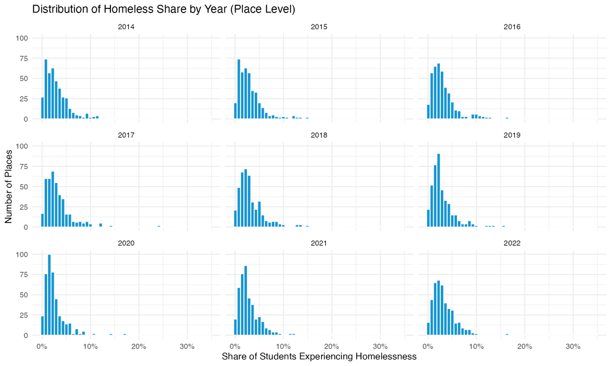

```r
# Distribution of homeless share by year
final_data |>
  filter(!is.na(homeless_share), homeless_share > 0, homeless_share < 0.5) |>
  ggplot(aes(x = homeless_share)) +
  geom_histogram(bins = 50, fill = "#1696d2", color = "white") +
  facet_wrap(~year) +
  scale_x_continuous(labels = scales::percent_format()) +
  labs(
    title = glue("Distribution of Homeless Share by Year ({str_to_title(params$geography)} Level)"),
    x = "Share of Students Experiencing Homelessness",
    y = glue("Number of {str_to_title(params$geography)}s")
  ) +
  theme_minimal()
```

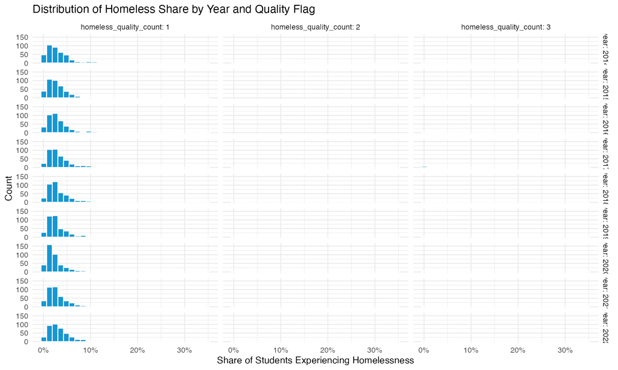

```r
# Distribution by quality level
final_data |>
  filter(!is.na(homeless_share), !is.na(homeless_quality_count),
         homeless_share > 0, homeless_share < 0.5) |>
  ggplot(aes(x = homeless_share)) +
  geom_histogram(bins = 30, fill = "#1696d2", color = "white") +
  facet_grid(year ~ homeless_quality_count, labeller = label_both) +
  scale_x_continuous(labels = scales::percent_format()) +
  labs(
    title = "Distribution of Homeless Share by Year and Quality Flag",
    x = "Share of Students Experiencing Homelessness",
    y = "Count"
  ) +
  theme_minimal()
```

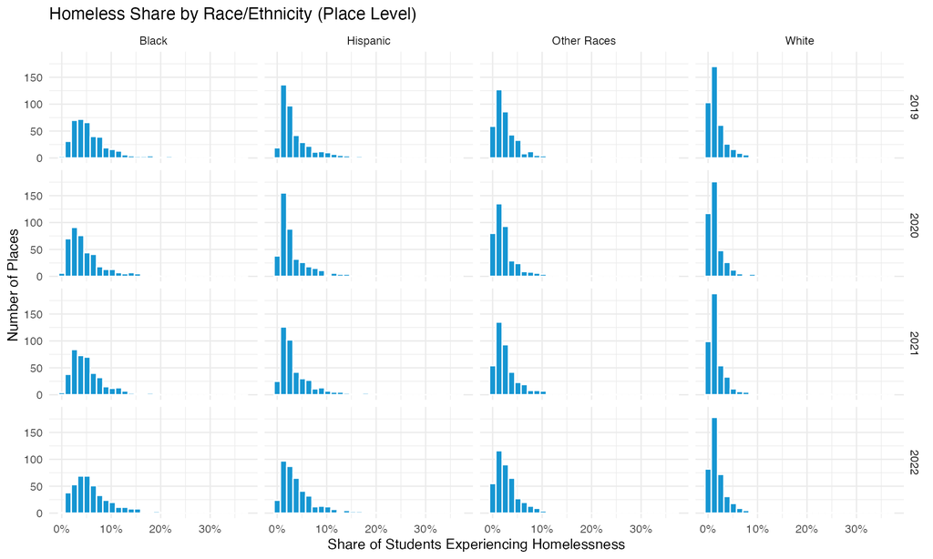

```r
# Distribution of homeless share by race/ethnicity subgroup
if (has_race_data) {
  final_data |>
    filter(year %in% race_years) |>
    select(year, state, !!settings$geo_var,
           black_share, white_share, hispanic_share, other_share) |>
    pivot_longer(
      cols = ends_with("_share"),
      names_to = "subgroup",
      values_to = "share"
    ) |>
    mutate(
      subgroup = subgroup |>
        str_remove("_share") |>
        str_to_title() |>
        recode("Other" = "Other Races")
    ) |>
    filter(!is.na(share), share > 0, share < 0.5) |>
    ggplot(aes(x = share)) +
    geom_histogram(bins = 30, fill = "#1696d2", color = "white") +
    facet_grid(year ~ subgroup) +
    scale_x_continuous(labels = scales::percent_format()) +
    labs(
      title = glue("Homeless Share by Race/Ethnicity ({str_to_title(params$geography)} Level)"),
      x = "Share of Students Experiencing Homelessness",
      y = glue("Number of {str_to_title(params$geography)}s")
    ) +
    theme_minimal()
}
```

## Export Final Data

```r
# Determine year range for file names
year_range <- glue("{min(available_years)}-{max(available_years)}")
geo_label <- if (params$geography == "place") "city" else "county"

# Prepare data for export (convert NA to empty string for CSV)
export_data <- final_data |>
  mutate(across(where(is.numeric), ~ as.character(round(.x, 10)))) |>
  mutate(across(everything(), ~ if_else(is.na(.x) | .x == "NA", "", .x)))

# Export final data (total homeless)
final_data_file <- here(
  final_dir,
  glue("homelessness_{year_range}_{geo_label}.csv")
)

final_data_export <- export_data |>
  select(
    year, state, !!settings$geo_var,
    count_homeless = homeless_count,
    count_homeless_lb = homeless_count_lb,
    count_homeless_ub = homeless_count_ub,
    share_homeless = homeless_share,
    count_homeless_quality = homeless_quality_count,
    share_homeless_quality = homeless_quality_share
  )

write_csv(final_data_export, final_data_file, na = "")
message(glue("Saved: {final_data_file}"))

# Export subgroup data (long format) - only for years with race data
if (has_race_data) {
  subgroup_year_range <- glue("{min(race_years)}-{max(race_years)}")
  subgroup_file <- here(
    final_dir,
    glue("homelessness_{subgroup_year_range}_subgroups_{geo_label}.csv")
  )

  # Filter to race years and reshape to long format
  export_subgroups <- export_data |>
    filter(year %in% race_years) |>
    select(
      year, state, !!settings$geo_var,
      homeless_count, homeless_count_lb, homeless_count_ub,
      homeless_share, homeless_quality_count, homeless_quality_share,
      black_count, black_count_lb, black_count_ub,
      black_share, black_quality_count, black_quality_share,
      white_count, white_count_lb, white_count_ub,
      white_share, white_quality_count, white_quality_share,
      hispanic_count, hispanic_count_lb, hispanic_count_ub,
      hispanic_share, hispanic_quality_count, hispanic_quality_share,
      other_count, other_count_lb, other_count_ub,
      other_share, other_quality_count, other_quality_share
    ) |>
    pivot_longer(
      cols = -c(year, state, !!settings$geo_var),
      names_to = c("subgroup", ".value"),
      names_pattern = "(homeless|black|white|hispanic|other)_(.*)"
    ) |>
    rename(
      count_homeless = count,
      count_homeless_lb = count_lb,
      count_homeless_ub = count_ub,
      share_homeless = share,
      count_homeless_quality = quality_count,
      share_homeless_quality = quality_share
    ) |>
    mutate(
      subgroup_type = if_else(subgroup == "homeless", "all", "race-ethnicity"),
      subgroup = case_when(
        subgroup == "homeless" ~ "All",
        subgroup == "black" ~ "Black, Non-Hispanic",
        subgroup == "white" ~ "White, Non-Hispanic",
        subgroup == "hispanic" ~ "Hispanic",
        subgroup == "other" ~ "Other Races and Ethnicities"
      )
    ) |>
    select(
      year, state, !!settings$geo_var, subgroup_type, subgroup,
      count_homeless, count_homeless_lb, count_homeless_ub,
      share_homeless, count_homeless_quality, share_homeless_quality
    ) |>
    arrange(year, state, .data[[settings$geo_var]], subgroup_type, subgroup)

  write_csv(export_subgroups, subgroup_file, na = "")
  message(glue("Saved: {subgroup_file}"))
}

message(glue("\n Export complete for {params$geography} geography!"))
```

## Final Data Evaluation

Enter the information into the `evaluate_final_data` function. Homeless students data do have confidence intervals and there are subgroup files.

```r
source(here::here("functions", "testing", "evaluate_final_data.R"))

final_data <- read_csv(final_data_file, show_col_types = FALSE)
if (has_race_data) {
  final_data_race <- read_csv(subgroup_file, show_col_types = FALSE)
}
```

### All

```r
evaluate_final_data(
  exp_form_path = glue("10a_final-evaluation/evaluation_form_homeless_student_{params$geography}.csv"),
  data = final_data,
  geography = params$geography,
  subgroups = FALSE,
  confidence_intervals = TRUE
)
```

```
[1] "This data passes all tests!"
```

### Subgroups

```r
evaluate_final_data(
  exp_form_path = glue("10a_final-evaluation/evaluation_form_homeless_student_race_eth_{params$geography}.csv"),
  data = final_data_race,
  geography = params$geography,
  subgroups = TRUE,
  confidence_intervals = TRUE
)
```

```
[1] "This data passes all tests!"
```